# 단일표본 T검정

# [1] 데이터프레임 4개 랜덤 생성

- [1-1] 10개 짜리 데이터 랜덤 생성 (=1번 데이터프레임)
  - [1-1-1] 『시리얼번호』 생성 ==> 1부터 10까지

```r
serialNumber1<-c(1:10)
serialNumber1
```

```
##  [1]  1  2  3  4  5  6  7  8  9 10
```

- [1-1-2] 『고혈압 수치』랜덤 생성 ==> 범위: 145~160

```r
SBP1<-c(sample(145:160, 10, replace=T))
SBP1
```

```
##  [1] 147 147 153 158 148 153 151 147 146 154
```

- [1-1-3] 데이터프레임으로 묶음: 『시리얼번호』와 『고혈압수치』를 하나의 데이터 프레임 안에다 엮음

```r
testData1<-data.frame(serialNumber1, SBP1)
testData1
```

```
##    serialNumber1 SBP1
## 1              1  147
## 2              2  147
## 3              3  153
## 4              4  158
## 5              5  148
## 6              6  153
## 7              7  151
## 8              8  147
## 9              9  146
## 10            10  154
```

```r
mean(testData1$SBP1)
```

```
## [1] 150.4
```

```r
str(testData1)
```

```
## 'data.frame':    10 obs. of  2 variables:
##  $ serialNumber1: int  1 2 3 4 5 6 7 8 9 10
##  $ SBP1         : int  147 147 153 158 148 153 151 147 146 154
```

# NA 0개임 확인

```r
summary(testData1$SBP1)
```

```
##    Min. 1st Qu.  Median    Mean 3rd Qu.    Max.
##   146.0   147.0   149.5   150.4   153.0   158.0
```

# NA를 제외한 평균

```r
mean(testData1$SBP1, na.rm = TRUE)
```

```
## [1] 150.4
```

# NA 제거 후 새로운 데이터 생성

```r
testData11 <- testData1[is.na(testData1$SBP1) == FALSE, ]
mean(testData11$SBP1)
```

```
## [1] 150.4
```

# [1-2] 30개 짜리 데이터 랜덤 생성 (=2번 데이터프레임)

```r
serialNumber2<-c(1:30)
serialNumber2
```

```
##  [1]  1  2  3  4  5  6  7  8  9 10 11 12 13 14 15 16 17 18 19 20 21 22 23 24 25
## [26] 26 27 28 29 30
```

```r
SBP2<-c(sample(145:160, 30, replace=T))
SBP2
```

```
##  [1] 156 148 155 157 151 154 150 153 158 151 145 158 155 152 156 159 156 153 145
## [20] 149 148 154 154 149 145 158 156 149 154 150
```

```r
testData2<-data.frame(serialNumber2, SBP2)
testData2
```

```
##    serialNumber2 SBP2
## 1              1  156
## 2              2  148
## 3              3  155
## 4              4  157
## 5              5  151
## 6              6  154
## 7              7  150
## 8              8  153
## 9              9  158
## 10            10  151
## 11            11  145
## 12            12  158
## 13            13  155
## 14            14  152
```

[output cut: 16 more lines]

```r
mean(testData2$SBP2)
```

```
## [1] 152.6
```

```r
str(testData2)
```

```
## 'data.frame':    30 obs. of  2 variables:
##  $ serialNumber2: int  1 2 3 4 5 6 7 8 9 10 ...
##  $ SBP2         : int  156 148 155 157 151 154 150 153 158 151 ...
```

```r
summary(testData2$SBP2)
```

```
##    Min. 1st Qu.  Median    Mean 3rd Qu.    Max.
##   145.0   149.2   153.5   152.6   156.0   159.0
```

```r
mean(testData2$SBP2, na.rm = TRUE)
```

```
## [1] 152.6
```

```r
testData22 <- testData2[is.na(testData2$SBP2) == FALSE, ]
mean(testData22$SBP2)
```

```
## [1] 152.6
```

# [1-3] 100개 짜리 데이터 랜덤 생성 (=3번 데이터프레임)

```r
serialNumber3<-c(1:100)
serialNumber3
```

```
##   [1]   1   2   3   4   5   6   7   8   9  10  11  12  13  14  15  16  17  18
##  [19]  19  20  21  22  23  24  25  26  27  28  29  30  31  32  33  34  35  36
##  [37]  37  38  39  40  41  42  43  44  45  46  47  48  49  50  51  52  53  54
##  [55]  55  56  57  58  59  60  61  62  63  64  65  66  67  68  69  70  71  72
##  [73]  73  74  75  76  77  78  79  80  81  82  83  84  85  86  87  88  89  90
##  [91]  91  92  93  94  95  96  97  98  99 100
```

```r
SBP3<-c(sample(145:160, 100, replace=T))
SBP3
```

```
##   [1] 159 148 154 156 149 158 156 151 150 158 152 149 148 156 153 147 154 146
##  [19] 145 147 154 160 159 151 156 147 148 159 156 155 148 152 152 156 154 158
##  [37] 155 153 148 154 158 147 150 146 146 146 156 146 158 158 159 158 158 157
##  [55] 154 149 152 148 148 151 152 158 147 158 160 153 145 156 158 154 154 156
##  [73] 148 157 160 155 154 160 150 150 151 153 151 156 155 145 154 150 150 152
##  [91] 145 160 152 152 149 150 145 151 156 150
```

```r
testData3<-data.frame(serialNumber3, SBP3)
testData3
```

```
##     serialNumber3 SBP3
## 1               1  159
## 2               2  148
## 3               3  154
## 4               4  156
## 5               5  149
## 6               6  158
## 7               7  156
## 8               8  151
## 9               9  150
## 10             10  158
## 11             11  152
## 12             12  149
## 13             13  148
## 14             14  156
```

[output cut: 86 more lines]

```r
mean(testData3$SBP3)
```

```
## [1] 152.68
```

```r
str(testData3)
```

```
## 'data.frame':    100 obs. of  2 variables:
##  $ serialNumber3: int  1 2 3 4 5 6 7 8 9 10 ...
##  $ SBP3         : int  159 148 154 156 149 158 156 151 150 158 ...
```

```r
summary(testData3$SBP3)
```

```
##    Min. 1st Qu.  Median    Mean 3rd Qu.    Max.
##   145.0   149.0   153.0   152.7   156.0   160.0
```

```r
mean(testData3$SBP3, na.rm = TRUE)
```

```
## [1] 152.68
```

```r
testData33 <- testData3[is.na(testData3$SBP3) == FALSE, ]
mean(testData33$SBP3)
```

```
## [1] 152.68
```

# [1-4] 1000개 짜리 데이터 랜덤 생성 (=4번 데이터프레임)

```r
serialNumber4<-c(1:1000)
serialNumber4
```

```
##    [1]    1    2    3    4    5    6    7    8    9   10   11   12   13   14
##   [15]   15   16   17   18   19   20   21   22   23   24   25   26   27   28
##   [29]   29   30   31   32   33   34   35   36   37   38   39   40   41   42
##   [43]   43   44   45   46   47   48   49   50   51   52   53   54   55   56
##   [57]   57   58   59   60   61   62   63   64   65   66   67   68   69   70
##   [71]   71   72   73   74   75   76   77   78   79   80   81   82   83   84
##   [85]   85   86   87   88   89   90   91   92   93   94   95   96   97   98
##   [99]   99  100  101  102  103  104  105  106  107  108  109  110  111  112
##  [113]  113  114  115  116  117  118  119  120  121  122  123  124  125  126
##  [127]  127  128  129  130  131  132  133  134  135  136  137  138  139  140
##  [141]  141  142  143  144  145  146  147  148  149  150  151  152  153  154
##  [155]  155  156  157  158  159  160  161  162  163  164  165  166  167  168
##  [169]  169  170  171  172  173  174  175  176  177  178  179  180  181  182
##  [183]  183  184  185  186  187  188  189  190  191  192  193  194  195  196
##  [197]  197  198  199  200  201  202  203  204  205  206  207  208  209  210
```

[output cut: 57 more lines]

```r
SBP4<-c(sample(145:160, 1000, replace=T))
SBP4
```

```
##    [1] 154 159 149 152 152 154 149 145 154 148 152 151 153 153 149 145 157 156
##   [19] 156 156 145 151 148 149 151 157 159 152 149 157 158 157 151 160 148 147
##   [37] 159 156 146 159 148 159 150 154 159 146 146 160 159 155 150 158 155 150
##   [55] 153 160 152 146 149 148 152 160 149 149 153 150 145 159 160 158 155 150
##   [73] 160 156 154 145 148 148 149 145 153 160 145 150 155 157 159 157 149 158
##   [91] 155 153 159 147 148 152 147 155 153 153 148 158 151 158 156 150 156 158
##  [109] 159 145 155 147 153 152 151 150 147 146 147 146 149 160 150 153 156 157
##  [127] 153 145 146 150 155 153 157 152 153 157 147 152 146 149 157 153 147 159
##  [145] 148 145 157 155 147 155 146 154 147 158 145 150 156 157 152 147 159 157
##  [163] 152 160 155 145 160 158 156 147 158 158 154 148 149 160 153 149 158 160
##  [181] 155 158 149 150 156 159 146 159 147 153 147 148 157 160 153 148 154 156
##  [199] 156 149 157 146 157 157 154 146 160 159 151 159 154 145 152 146 156 151
##  [217] 146 160 156 155 149 148 160 150 148 149 160 149 149 153 157 149 152 145
##  [235] 157 145 145 159 148 146 153 146 145 150 154 159 155 157 153 147 150 154
##  [253] 159 155 159 151 146 150 147 151 146 148 154 159 151 155 145 159 158 156
```

[output cut: 41 more lines]

```r
testData4<-data.frame(serialNumber4, SBP4)
testData4
```

```
##      serialNumber4 SBP4
## 1                1  154
## 2                2  159
## 3                3  149
## 4                4  152
## 5                5  152
## 6                6  154
## 7                7  149
## 8                8  145
## 9                9  154
## 10              10  148
## 11              11  152
## 12              12  151
## 13              13  153
## 14              14  153
```

[output cut: 986 more lines]

```r
mean(testData4$SBP4)
```

```
## [1] 152.646
```

```r
str(testData4)
```

```
## 'data.frame':    1000 obs. of  2 variables:
##  $ serialNumber4: int  1 2 3 4 5 6 7 8 9 10 ...
##  $ SBP4         : int  154 159 149 152 152 154 149 145 154 148 ...
```

```r
summary(testData4$SBP4)
```

```
##    Min. 1st Qu.  Median    Mean 3rd Qu.    Max.
##   145.0   149.0   153.0   152.6   157.0   160.0
```

```r
mean(testData4$SBP4, na.rm = TRUE)
```

```
## [1] 152.646
```

```r
testData44 <- testData4[is.na(testData4$SBP4) == FALSE, ]
mean(testData44$SBP4)
```

```
## [1] 152.646
```

# [2] Shapiro 테스트 (정규분포 검정)

- ▷ 귀무가설: 수축기혈압의 각 수치들(데이터 testData1$SBP1 ~ testData4$SBP4)은 정규분포를 보인다.
- ▶ 대립가설: 데이터프레임 testData1은 정규분포를 보이지 않는다.
- 즉, p-Value(유의확률)값이 0.05보다 크면 데이터프레임 dat은 정규분포를 보인다는 뜻임

```r
shapiro.test(testData11$SBP1)
```

```
##
##  Shapiro-Wilk normality test
##
## data:  testData11$SBP1
## W = 0.88906, p-value = 0.1655
```

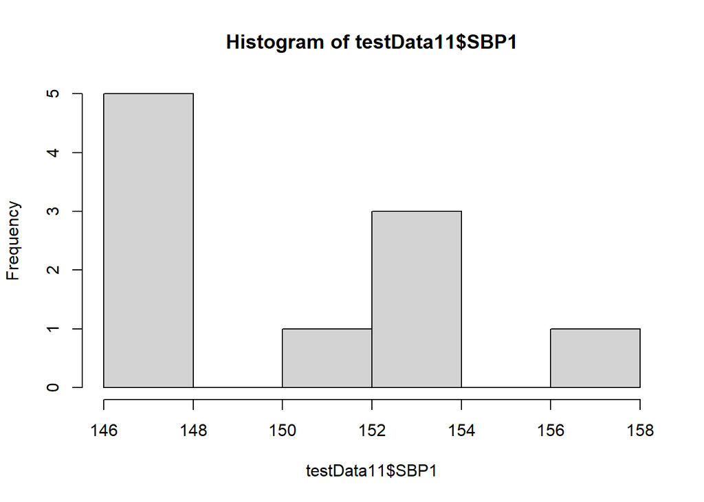

```r
hist(testData11$SBP1)
```

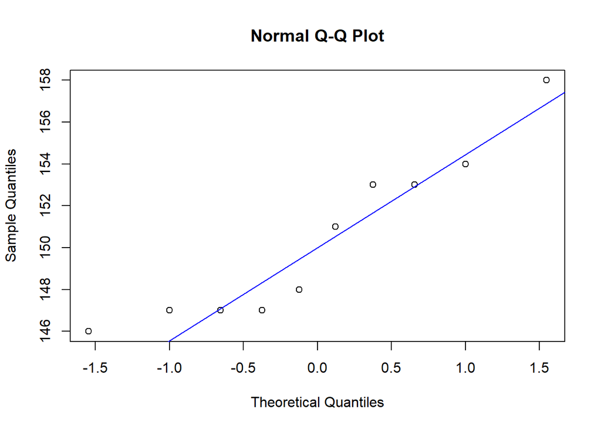

```r
qqnorm(testData11$SBP1)
qqline(testData1$SBP1, lty = 1, col = "blue")
```

```r
shapiro.test(testData22$SBP2)
```

```
##
##  Shapiro-Wilk normality test
##
## data:  testData22$SBP2
## W = 0.94718, p-value = 0.142
```

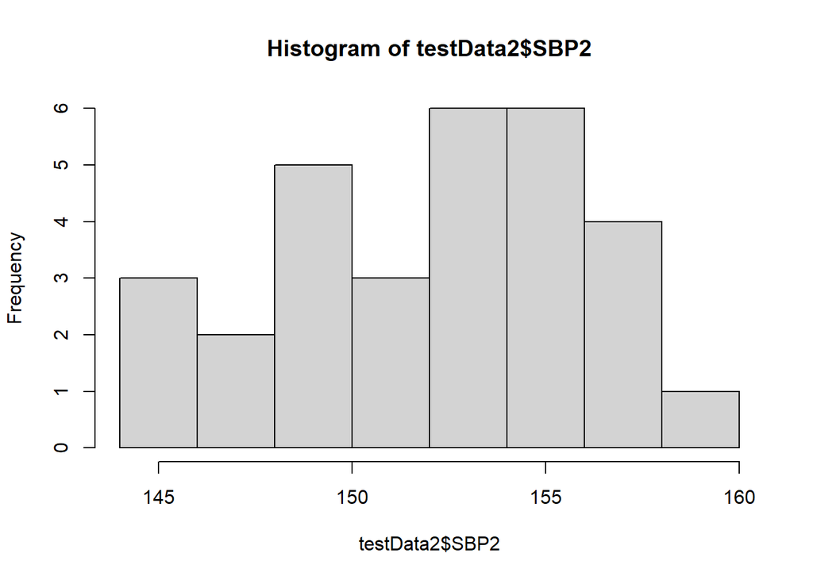

```r
hist(testData2$SBP2)
```

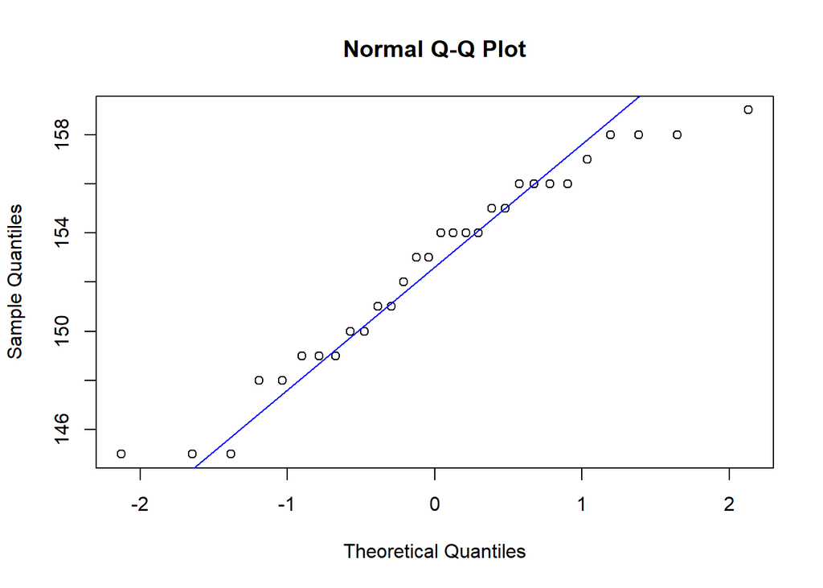

```r
qqnorm(testData2$SBP2)
qqline(testData2$SBP2, lty = 1, col = "blue")
```

```r
shapiro.test(testData33$SBP3)
```

```
##
##  Shapiro-Wilk normality test
##
## data:  testData33$SBP3
## W = 0.95359, p-value = 0.001441
```

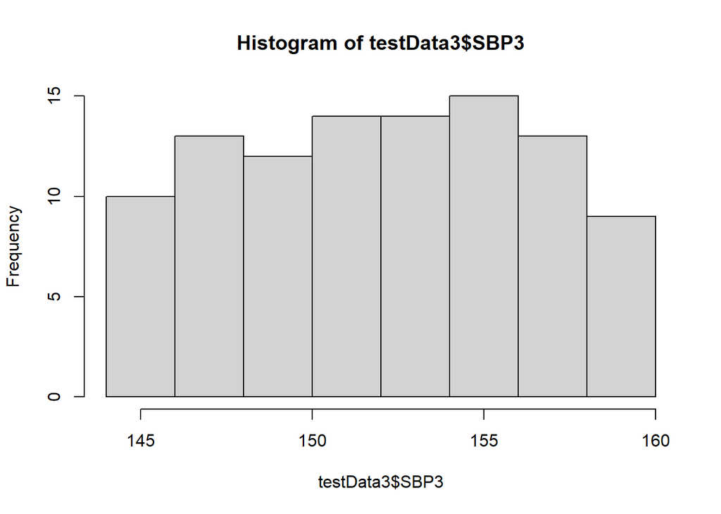

```r
hist(testData3$SBP3)
```

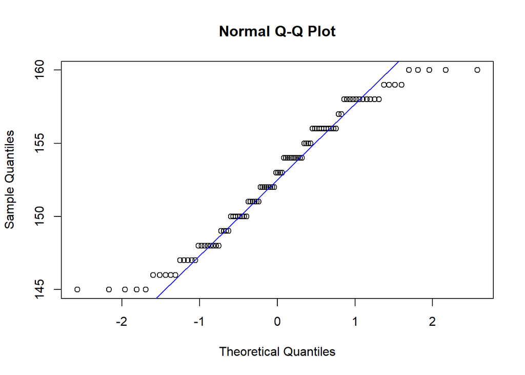

```r
qqnorm(testData3$SBP3)
qqline(testData3$SBP3, lty = 1, col = "blue")
```

```r
shapiro.test(testData44$SBP4)
```

```
##
##  Shapiro-Wilk normality test
##
## data:  testData44$SBP4
## W = 0.94267, p-value < 2.2e-16
```

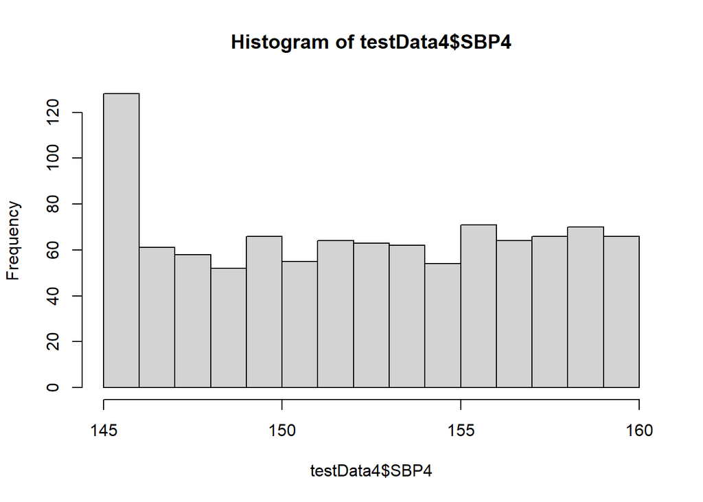

```r
hist(testData4$SBP4)
```

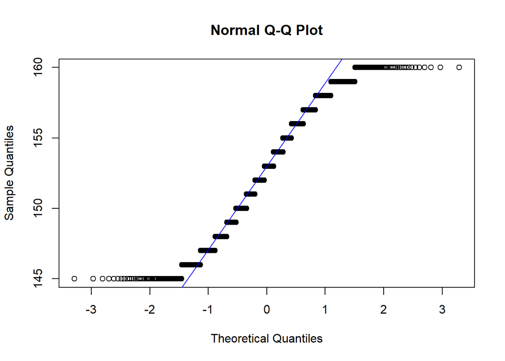

```r
qqnorm(testData4$SBP4)
qqline(testData4$SBP4, lty = 1, col = "blue")
```

# [3] 단일표본 T검정

- 1번 데이터프레임
- 평균

```r
mean(testData11$SBP1)
```

```
## [1] 150.4
```

- 양측 T검정

```r
t.test(testData11$SBP1, alternative = "two.sided", mu = 150, paired = FALSE, var.equal = FALSE, conf.level = 0.95)
```

```
##
##  One Sample t-test
##
## data:  testData11$SBP1
## t = 0.31579, df = 9, p-value = 0.7594
## alternative hypothesis: true mean is not equal to 150
## 95 percent confidence interval:
##  147.5346 153.2654
## sample estimates:
## mean of x
##     150.4
```

- 단측 T검정

```r
t.test(testData11$SBP1, alternative = "greater", mu = 150, paired = FALSE, var.equal = FALSE, conf.level = 0.95)
```

```
##
##  One Sample t-test
##
## data:  testData11$SBP1
## t = 0.31579, df = 9, p-value = 0.3797
## alternative hypothesis: true mean is greater than 150
## 95 percent confidence interval:
##  148.0781      Inf
## sample estimates:
## mean of x
##     150.4
```

```r
t.test(testData11$SBP1, alternative = "less", mu = 150, paired = FALSE, var.equal = FALSE, conf.level = 0.95)
```

```
##
##  One Sample t-test
##
## data:  testData11$SBP1
## t = 0.31579, df = 9, p-value = 0.6203
## alternative hypothesis: true mean is less than 150
## 95 percent confidence interval:
##      -Inf 152.7219
## sample estimates:
## mean of x
##     150.4
```

- 양측 Wilcox 검정

```r
wilcox.test(testData11$SBP1, alternative = "two.sided", mu = 150, paired = FALSE, conf.level = 0.95)
```

```
##
##  Wilcoxon signed rank test with continuity correction
##
## data:  testData11$SBP1
## V = 29.5, p-value = 0.8768
## alternative hypothesis: true location is not equal to 150
```

- 단측 Wilcox 검정

```r
wilcox.test(testData11$SBP1, alternative = "greater", mu = 150, paired = FALSE, conf.level = 0.95)
```

```
##
##  Wilcoxon signed rank test with continuity correction
##
## data:  testData11$SBP1
## V = 29.5, p-value = 0.4384
## alternative hypothesis: true location is greater than 150
```

```r
wilcox.test(testData11$SBP1, alternative = "less", mu = 150, paired = FALSE, conf.level = 0.95)
```

```
##
##  Wilcoxon signed rank test with continuity correction
##
## data:  testData11$SBP1
## V = 29.5, p-value = 0.6019
## alternative hypothesis: true location is less than 150
```

- 2번 데이터프레임
- 평균

```r
mean(testData22$SBP2)
```

```
## [1] 152.6
```

- 양측 T검정

```r
t.test(testData22$SBP2, alternative = "two.sided", mu = 150, paired = FALSE, var.equal = FALSE, conf.level = 0.95)
```

```
##
##  One Sample t-test
##
## data:  testData22$SBP2
## t = 3.4744, df = 29, p-value = 0.00163
## alternative hypothesis: true mean is not equal to 150
## 95 percent confidence interval:
##  151.0695 154.1305
## sample estimates:
## mean of x
##     152.6
```

- 단측 T검정

```r
t.test(testData22$SBP2, alternative = "greater", mu = 150, paired = FALSE, var.equal = FALSE, conf.level = 0.95)
```

```
##
##  One Sample t-test
##
## data:  testData22$SBP2
## t = 3.4744, df = 29, p-value = 0.0008152
## alternative hypothesis: true mean is greater than 150
## 95 percent confidence interval:
##  151.3285      Inf
## sample estimates:
## mean of x
##     152.6
```

```r
t.test(testData22$SBP2, alternative = "less", mu = 150, paired = FALSE, var.equal = FALSE, conf.level = 0.95)
```

```
##
##  One Sample t-test
##
## data:  testData22$SBP2
## t = 3.4744, df = 29, p-value = 0.9992
## alternative hypothesis: true mean is less than 150
## 95 percent confidence interval:
##      -Inf 153.8715
## sample estimates:
## mean of x
##     152.6
```

- 양측 Wilcox 검정

```r
wilcox.test(testData22$SBP2, alternative = "two.sided", mu = 150, paired = FALSE, conf.level = 0.95)
```

```
##
##  Wilcoxon signed rank test with continuity correction
##
## data:  testData22$SBP2
## V = 332, p-value = 0.00336
## alternative hypothesis: true location is not equal to 150
```

- 단측 Wilcox 검정

```r
wilcox.test(testData22$SBP2, alternative = "greater", mu = 150, paired = FALSE, conf.level = 0.95)
```

```
##
##  Wilcoxon signed rank test with continuity correction
##
## data:  testData22$SBP2
## V = 332, p-value = 0.00168
## alternative hypothesis: true location is greater than 150
```

```r
wilcox.test(testData22$SBP2, alternative = "less", mu = 150, paired = FALSE, conf.level = 0.95)
```

```
##
##  Wilcoxon signed rank test with continuity correction
##
## data:  testData22$SBP2
## V = 332, p-value = 0.9984
## alternative hypothesis: true location is less than 150
```

- 3번 데이터프레임
- 평균

```r
mean(testData33$SBP3)
```

```
## [1] 152.68
```

- 양측 T검정

```r
t.test(testData33$SBP3, alternative = "two.sided", mu = 150, paired = FALSE, var.equal = FALSE, conf.level = 0.95)
```

```
##
##  One Sample t-test
##
## data:  testData33$SBP3
## t = 6.0796, df = 99, p-value = 2.264e-08
## alternative hypothesis: true mean is not equal to 150
## 95 percent confidence interval:
##  151.8053 153.5547
## sample estimates:
## mean of x
##    152.68
```

- 단측 T검정

```r
t.test(testData33$SBP3, alternative = "greater", mu = 150, paired = FALSE, var.equal = FALSE, conf.level = 0.95)
```

```
##
##  One Sample t-test
##
## data:  testData33$SBP3
## t = 6.0796, df = 99, p-value = 1.132e-08
## alternative hypothesis: true mean is greater than 150
## 95 percent confidence interval:
##  151.9481      Inf
## sample estimates:
## mean of x
##    152.68
```

```r
t.test(testData33$SBP3, alternative = "less", mu = 150, paired = FALSE, var.equal = FALSE, conf.level = 0.95)
```

```
##
##  One Sample t-test
##
## data:  testData33$SBP3
## t = 6.0796, df = 99, p-value = 1
## alternative hypothesis: true mean is less than 150
## 95 percent confidence interval:
##      -Inf 153.4119
## sample estimates:
## mean of x
##    152.68
```

- 양측 Wilcox 검정

```r
wilcox.test(testData33$SBP3, alternative = "two.sided", mu = 150, paired = FALSE, conf.level = 0.95)
```

```
##
##  Wilcoxon signed rank test with continuity correction
##
## data:  testData33$SBP3
## V = 3463, p-value = 2.418e-07
## alternative hypothesis: true location is not equal to 150
```

- 단측 Wilcox 검정

```r
wilcox.test(testData33$SBP3, alternative = "greater", mu = 150, paired = FALSE, conf.level = 0.95)
```

```
##
##  Wilcoxon signed rank test with continuity correction
##
## data:  testData33$SBP3
## V = 3463, p-value = 1.209e-07
## alternative hypothesis: true location is greater than 150
```

```r
wilcox.test(testData33$SBP3, alternative = "less", mu = 150, paired = FALSE, conf.level = 0.95)
```

```
##
##  Wilcoxon signed rank test with continuity correction
##
## data:  testData33$SBP3
## V = 3463, p-value = 1
## alternative hypothesis: true location is less than 150
```

- 4번 데이터프레임
- 평균

```r
mean(testData44$SBP4)
```

```
## [1] 152.646
```

- 양측 T검정

```r
t.test(testData44$SBP4, alternative = "two.sided", mu = 150, paired = FALSE, var.equal = FALSE, conf.level = 0.95)
```

```
##
##  One Sample t-test
##
## data:  testData44$SBP4
## t = 17.854, df = 999, p-value < 2.2e-16
## alternative hypothesis: true mean is not equal to 150
## 95 percent confidence interval:
##  152.3552 152.9368
## sample estimates:
## mean of x
##   152.646
```

- 단측 T검정

```r
t.test(testData44$SBP4, alternative = "greater", mu = 150, paired = FALSE, var.equal = FALSE, conf.level = 0.95)
```

```
##
##  One Sample t-test
##
## data:  testData44$SBP4
## t = 17.854, df = 999, p-value < 2.2e-16
## alternative hypothesis: true mean is greater than 150
## 95 percent confidence interval:
##  152.402     Inf
## sample estimates:
## mean of x
##   152.646
```

```r
t.test(testData44$SBP4, alternative = "less", mu = 150, paired = FALSE, var.equal = FALSE, conf.level = 0.95)
```

```
##
##  One Sample t-test
##
## data:  testData44$SBP4
## t = 17.854, df = 999, p-value = 1
## alternative hypothesis: true mean is less than 150
## 95 percent confidence interval:
##    -Inf 152.89
## sample estimates:
## mean of x
##   152.646
```

- 양측 Wilcox 검정

```r
wilcox.test(testData44$SBP4, alternative = "two.sided", mu = 150, paired = FALSE, conf.level = 0.95)
```

```
##
##  Wilcoxon signed rank test with continuity correction
##
## data:  testData44$SBP4
## V = 344641, p-value < 2.2e-16
## alternative hypothesis: true location is not equal to 150
```

- 단측 Wilcox 검정

```r
wilcox.test(testData44$SBP4, alternative = "greater", mu = 150, paired = FALSE, conf.level = 0.95)
```

```
##
##  Wilcoxon signed rank test with continuity correction
##
## data:  testData44$SBP4
## V = 344641, p-value < 2.2e-16
## alternative hypothesis: true location is greater than 150
```

```r
wilcox.test(testData44$SBP4, alternative = "less", mu = 150, paired = FALSE, conf.level = 0.95)
```

```
##
##  Wilcoxon signed rank test with continuity correction
##
## data:  testData44$SBP4
## V = 344641, p-value = 1
## alternative hypothesis: true location is less than 150
```